# Conditional Statements Revisited

## Outline

- Or Conditional
- And Conditional
- Not Conditional

We will now expand our use of conditional statements by allowing for multiple conditions.

**Reminders:**

1) Use print statements check what your code is doing (or not doing) as you write it

2) Comment your code!

```python
# load packages
import numpy as np
import matplotlib.pyplot as plt
import time
```

## Or Conditionals

We can check multiple statements using the `or` statement. Let's see this in a simple `if` statement (no functions).

```python
x = -4

if x > 0 or x < 0:
    print('positive or negative')
```

```
positive or negative
```

**Practice!** Write a function that uses an `or` statement

## And Conditionals

Similarly, if you want to check more than one statement, you can do so in `if` statements by including `and`.

```python
def myfun(x):
    # this checks if x is between 0 and 3
    if x > 0 and x < 3:
        #print(x)
        return x
    else:
        return x - 5
```

```python
myfun(2.0) + myfun(1)
```

```
3.0
```

**Practice!** Write a function (with comments) that returns the number only if the input is an integer and is divisible by 3.

## Not Conditionals

```python
x = 3
if not x == 3:
    print(x)
```

```python
x = 5
if x != 3:
    print(x)
```

```
5
```

**Practice!** Write a function (with comments) that incorporates the `not` or `!=` conditional.

**Practice!** Write two different functions that uses all 3 (`or, and, not`) - in different order. What do you think the order of operations is? In other words, what order does the computer perform `or, and, not`?

```python
y = np.zeros(1000)
for i in range(1000):
    y[i] = myfun(i)
```

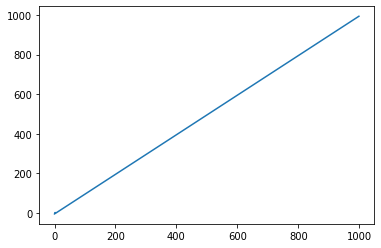

```python
plt.plot(np.arange(0,1000), y)
```

```python
# Is the order
# AON - 1
# ANO - 0
# NAO - 6
# NOA - 0
# Left to Right - 4
# OAN - 1
# ONA - 0
```